# Risk Factor Analysis

## Outcome Variable

**Outcome Variable:** wast_rec90d

## Predictor Variables

**Intervention Variable:** impfloor

**Adjustment Set:**

- arm
- sex
- W_mage
- meducyrs
- feducyrs
- hhwealth_quart
- hfoodsec
- W_mhtcm
- W_nrooms
- W_nchldlt5
- W_parity
- impsan
- safeh20
- delta_W_mage
- delta_meducyrs
- delta_feducyrs
- delta_hhwealth_quart
- delta_hfoodsec
- delta_W_mhtcm
- delta_W_nrooms
- delta_W_nchldlt5
- delta_W_parity
- delta_impsan
- delta_safeh20

## Stratifying Variables

The analysis was stratified on these variable(s):

- agecat
- studyid
- country

## Data Summary

| agecat | studyid | country | impfloor | wast_rec90d | n_cell | n |
| --- | --- | --- | --- | --- | --- | --- |
| 0-24 months | ki0047075b-MAL-ED | BANGLADESH | 0 | 0 | 6 | 121 |
| 0-24 months | ki0047075b-MAL-ED | BANGLADESH | 0 | 1 | 4 | 121 |
| 0-24 months | ki0047075b-MAL-ED | BANGLADESH | 1 | 0 | 38 | 121 |
| 0-24 months | ki0047075b-MAL-ED | BANGLADESH | 1 | 1 | 73 | 121 |
| 0-24 months | ki0047075b-MAL-ED | BRAZIL | 0 | 0 | 0 | 23 |
| 0-24 months | ki0047075b-MAL-ED | BRAZIL | 0 | 1 | 0 | 23 |
| 0-24 months | ki0047075b-MAL-ED | BRAZIL | 1 | 0 | 6 | 23 |
| 0-24 months | ki0047075b-MAL-ED | BRAZIL | 1 | 1 | 17 | 23 |
| 0-24 months | ki0047075b-MAL-ED | INDIA | 0 | 0 | 6 | 173 |
| 0-24 months | ki0047075b-MAL-ED | INDIA | 0 | 1 | 9 | 173 |
| 0-24 months | ki0047075b-MAL-ED | INDIA | 1 | 0 | 61 | 173 |
| 0-24 months | ki0047075b-MAL-ED | INDIA | 1 | 1 | 97 | 173 |
| 0-24 months | ki0047075b-MAL-ED | NEPAL | 0 | 0 | 10 | 87 |
| 0-24 months | ki0047075b-MAL-ED | NEPAL | 0 | 1 | 36 | 87 |
| 0-24 months | ki0047075b-MAL-ED | NEPAL | 1 | 0 | 9 | 87 |
| 0-24 months | ki0047075b-MAL-ED | NEPAL | 1 | 1 | 32 | 87 |
| 0-24 months | ki0047075b-MAL-ED | PERU | 0 | 0 | 4 | 33 |
| 0-24 months | ki0047075b-MAL-ED | PERU | 0 | 1 | 22 | 33 |
| 0-24 months | ki0047075b-MAL-ED | PERU | 1 | 0 | 2 | 33 |
| 0-24 months | ki0047075b-MAL-ED | PERU | 1 | 1 | 5 | 33 |
| 0-24 months | ki0047075b-MAL-ED | SOUTH AFRICA | 0 | 0 | 0 | 77 |
| 0-24 months | ki0047075b-MAL-ED | SOUTH AFRICA | 0 | 1 | 3 | 77 |
| 0-24 months | ki0047075b-MAL-ED | SOUTH AFRICA | 1 | 0 | 12 | 77 |
| 0-24 months | ki0047075b-MAL-ED | SOUTH AFRICA | 1 | 1 | 62 | 77 |
| 0-24 months | ki0047075b-MAL-ED | TANZANIA, UNITED REPUBLIC OF | 0 | 0 | 8 | 45 |
| 0-24 months | ki0047075b-MAL-ED | TANZANIA, UNITED REPUBLIC OF | 0 | 1 | 36 | 45 |
| 0-24 months | ki0047075b-MAL-ED | TANZANIA, UNITED REPUBLIC OF | 1 | 0 | 0 | 45 |
| 0-24 months | ki0047075b-MAL-ED | TANZANIA, UNITED REPUBLIC OF | 1 | 1 | 1 | 45 |
| 0-24 months | ki1000108-CMC-V-BCS-2002 | INDIA | 0 | 0 | 0 | 225 |
| 0-24 months | ki1000108-CMC-V-BCS-2002 | INDIA | 0 | 1 | 0 | 225 |

[output cut: 162 more lines]

The following strata were considered:

- agecat: 0-24 months, studyid: ki0047075b-MAL-ED, country: BANGLADESH
- agecat: 0-24 months, studyid: ki0047075b-MAL-ED, country: BRAZIL
- agecat: 0-24 months, studyid: ki0047075b-MAL-ED, country: INDIA
- agecat: 0-24 months, studyid: ki0047075b-MAL-ED, country: NEPAL
- agecat: 0-24 months, studyid: ki0047075b-MAL-ED, country: PERU
- agecat: 0-24 months, studyid: ki0047075b-MAL-ED, country: SOUTH AFRICA
- agecat: 0-24 months, studyid: ki0047075b-MAL-ED, country: TANZANIA, UNITED REPUBLIC OF
- agecat: 0-24 months, studyid: ki1000108-CMC-V-BCS-2002, country: INDIA
- agecat: 0-24 months, studyid: ki1000108-IRC, country: INDIA
- agecat: 0-24 months, studyid: ki1017093-NIH-Birth, country: BANGLADESH
- agecat: 0-24 months, studyid: ki1017093b-PROVIDE, country: BANGLADESH
- agecat: 0-24 months, studyid: ki1017093c-NIH-Crypto, country: BANGLADESH
- agecat: 0-24 months, studyid: ki1113344-GMS-Nepal, country: NEPAL
- agecat: 0-24 months, studyid: ki1114097-CONTENT, country: PERU
- agecat: 0-24 months, studyid: kiGH5241-JiVitA-3, country: BANGLADESH
- agecat: 0-24 months, studyid: kiGH5241-JiVitA-4, country: BANGLADESH
- agecat: 0-6 months, studyid: ki0047075b-MAL-ED, country: BANGLADESH
- agecat: 0-6 months, studyid: ki0047075b-MAL-ED, country: BRAZIL
- agecat: 0-6 months, studyid: ki0047075b-MAL-ED, country: INDIA
- agecat: 0-6 months, studyid: ki0047075b-MAL-ED, country: NEPAL
- agecat: 0-6 months, studyid: ki0047075b-MAL-ED, country: PERU
- agecat: 0-6 months, studyid: ki0047075b-MAL-ED, country: SOUTH AFRICA
- agecat: 0-6 months, studyid: ki0047075b-MAL-ED, country: TANZANIA, UNITED REPUBLIC OF
- agecat: 0-6 months, studyid: ki1000108-CMC-V-BCS-2002, country: INDIA
- agecat: 0-6 months, studyid: ki1000108-IRC, country: INDIA
- agecat: 0-6 months, studyid: ki1017093-NIH-Birth, country: BANGLADESH
- agecat: 0-6 months, studyid: ki1017093b-PROVIDE, country: BANGLADESH
- agecat: 0-6 months, studyid: ki1017093c-NIH-Crypto, country: BANGLADESH
- agecat: 0-6 months, studyid: ki1113344-GMS-Nepal, country: NEPAL
- agecat: 0-6 months, studyid: ki1114097-CONTENT, country: PERU
- agecat: 0-6 months, studyid: kiGH5241-JiVitA-3, country: BANGLADESH
- agecat: 0-6 months, studyid: kiGH5241-JiVitA-4, country: BANGLADESH
- agecat: 6-24 months, studyid: ki0047075b-MAL-ED, country: BANGLADESH
- agecat: 6-24 months, studyid: ki0047075b-MAL-ED, country: BRAZIL
- agecat: 6-24 months, studyid: ki0047075b-MAL-ED, country: INDIA
- agecat: 6-24 months, studyid: ki0047075b-MAL-ED, country: NEPAL
- agecat: 6-24 months, studyid: ki0047075b-MAL-ED, country: PERU
- agecat: 6-24 months, studyid: ki0047075b-MAL-ED, country: SOUTH AFRICA
- agecat: 6-24 months, studyid: ki0047075b-MAL-ED, country: TANZANIA, UNITED REPUBLIC OF
- agecat: 6-24 months, studyid: ki1000108-CMC-V-BCS-2002, country: INDIA
- agecat: 6-24 months, studyid: ki1000108-IRC, country: INDIA
- agecat: 6-24 months, studyid: ki1017093-NIH-Birth, country: BANGLADESH
- agecat: 6-24 months, studyid: ki1017093b-PROVIDE, country: BANGLADESH
- agecat: 6-24 months, studyid: ki1017093c-NIH-Crypto, country: BANGLADESH
- agecat: 6-24 months, studyid: ki1113344-GMS-Nepal, country: NEPAL
- agecat: 6-24 months, studyid: ki1114097-CONTENT, country: PERU
- agecat: 6-24 months, studyid: kiGH5241-JiVitA-3, country: BANGLADESH
- agecat: 6-24 months, studyid: kiGH5241-JiVitA-4, country: BANGLADESH

### Dropped Strata

Some strata were dropped due to rare outcomes:

- agecat: 0-24 months, studyid: ki0047075b-MAL-ED, country: BANGLADESH
- agecat: 0-24 months, studyid: ki0047075b-MAL-ED, country: BRAZIL
- agecat: 0-24 months, studyid: ki0047075b-MAL-ED, country: PERU
- agecat: 0-24 months, studyid: ki0047075b-MAL-ED, country: SOUTH AFRICA
- agecat: 0-24 months, studyid: ki0047075b-MAL-ED, country: TANZANIA, UNITED REPUBLIC OF
- agecat: 0-24 months, studyid: ki1000108-CMC-V-BCS-2002, country: INDIA
- agecat: 0-24 months, studyid: ki1000108-IRC, country: INDIA
- agecat: 0-24 months, studyid: ki1114097-CONTENT, country: PERU
- agecat: 0-6 months, studyid: ki0047075b-MAL-ED, country: BANGLADESH
- agecat: 0-6 months, studyid: ki0047075b-MAL-ED, country: BRAZIL
- agecat: 0-6 months, studyid: ki0047075b-MAL-ED, country: INDIA
- agecat: 0-6 months, studyid: ki0047075b-MAL-ED, country: NEPAL
- agecat: 0-6 months, studyid: ki0047075b-MAL-ED, country: PERU
- agecat: 0-6 months, studyid: ki0047075b-MAL-ED, country: SOUTH AFRICA
- agecat: 0-6 months, studyid: ki0047075b-MAL-ED, country: TANZANIA, UNITED REPUBLIC OF
- agecat: 0-6 months, studyid: ki1000108-CMC-V-BCS-2002, country: INDIA
- agecat: 0-6 months, studyid: ki1000108-IRC, country: INDIA
- agecat: 0-6 months, studyid: ki1017093c-NIH-Crypto, country: BANGLADESH
- agecat: 0-6 months, studyid: ki1114097-CONTENT, country: PERU
- agecat: 6-24 months, studyid: ki0047075b-MAL-ED, country: BANGLADESH
- agecat: 6-24 months, studyid: ki0047075b-MAL-ED, country: BRAZIL
- agecat: 6-24 months, studyid: ki0047075b-MAL-ED, country: NEPAL
- agecat: 6-24 months, studyid: ki0047075b-MAL-ED, country: PERU
- agecat: 6-24 months, studyid: ki0047075b-MAL-ED, country: SOUTH AFRICA
- agecat: 6-24 months, studyid: ki0047075b-MAL-ED, country: TANZANIA, UNITED REPUBLIC OF
- agecat: 6-24 months, studyid: ki1000108-CMC-V-BCS-2002, country: INDIA
- agecat: 6-24 months, studyid: ki1000108-IRC, country: INDIA
- agecat: 6-24 months, studyid: ki1017093b-PROVIDE, country: BANGLADESH
- agecat: 6-24 months, studyid: ki1017093c-NIH-Crypto, country: BANGLADESH
- agecat: 6-24 months, studyid: ki1114097-CONTENT, country: PERU
- agecat: 6-24 months, studyid: kiGH5241-JiVitA-3, country: BANGLADESH

## Methods Detail

We’re interested in the causal parameters $E[Y_a]$ for all values of $a \in \mathcal{A}$. These parameters represent the mean outcome if, possibly contrary to fact, we intervened to set all units to have $A=a$. Under the randomization and positivity assumptions, these are identified by the statistical parameters $\psi_a=E_W[E_{Y|A,W}(Y|A=a,W)]$. In addition, we’re interested in the mean of $Y$, $E[Y]$ under no intervention (the observed mean). We will estimate these parameters by using SuperLearner to fit the relevant likelihood factors – $E_{Y|A,W}(Y|A=a,W)$ and $p(A=a|W)$, and then updating our likelihood fit using a joint TMLE.

For unadjusted analyses ($W=\{\}$), initial likelihoods were estimated using Lrnr_glm to estimate the simple $E(Y|A)$ and Lrnr_mean to estimate $p(A)$. For adjusted analyses, a small library containing Lrnr_glmnet, Lrnr_xgboost, and Lrnr_mean was used.

Having estimated these parameters, we will then use the delta method to estimate relative risks and attributable risks relative to a prespecified baseline level of $A$.

# Results Detail

## Results Plots

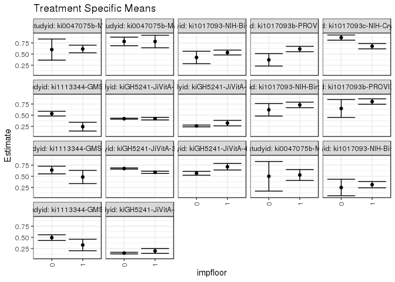

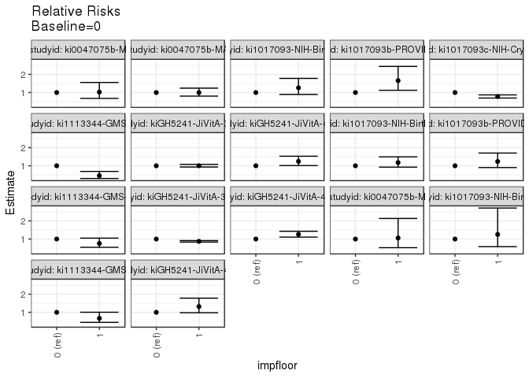

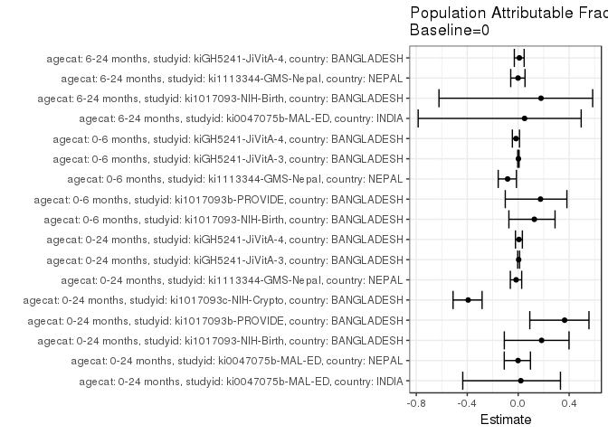

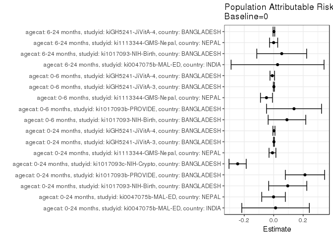

## Results Table

### Parameter: TSM

| agecat | studyid | country | intervention_level | baseline_level | estimate | ci_lower | ci_upper |
| --- | --- | --- | --- | --- | --- | --- | --- |
| 0-24 months | ki0047075b-MAL-ED | INDIA | 0 | NA | 0.6000000 | 0.3636292 | 0.8363708 |
| 0-24 months | ki0047075b-MAL-ED | INDIA | 1 | NA | 0.6139241 | 0.5287779 | 0.6990702 |
| 0-24 months | ki0047075b-MAL-ED | NEPAL | 0 | NA | 0.7826087 | 0.6870003 | 0.8782171 |
| 0-24 months | ki0047075b-MAL-ED | NEPAL | 1 | NA | 0.7804878 | 0.6404037 | 0.9205719 |
| 0-24 months | ki1017093-NIH-Birth | BANGLADESH | 0 | NA | 0.4237736 | 0.2843228 | 0.5632245 |
| 0-24 months | ki1017093-NIH-Birth | BANGLADESH | 1 | NA | 0.5341850 | 0.4798749 | 0.5884952 |
| 0-24 months | ki1017093b-PROVIDE | BANGLADESH | 0 | NA | 0.3705693 | 0.2315733 | 0.5095653 |
| 0-24 months | ki1017093b-PROVIDE | BANGLADESH | 1 | NA | 0.6130776 | 0.5524698 | 0.6736853 |
| 0-24 months | ki1017093c-NIH-Crypto | BANGLADESH | 0 | NA | 0.8687395 | 0.8107749 | 0.9267042 |
| 0-24 months | ki1017093c-NIH-Crypto | BANGLADESH | 1 | NA | 0.6756741 | 0.6163865 | 0.7349616 |
| 0-24 months | ki1113344-GMS-Nepal | NEPAL | 0 | NA | 0.5343389 | 0.4813518 | 0.5873261 |
| 0-24 months | ki1113344-GMS-Nepal | NEPAL | 1 | NA | 0.2432505 | 0.1456564 | 0.3408447 |
| 0-24 months | kiGH5241-JiVitA-3 | BANGLADESH | 0 | NA | 0.4214526 | 0.4100298 | 0.4328754 |
| 0-24 months | kiGH5241-JiVitA-3 | BANGLADESH | 1 | NA | 0.4229092 | 0.3940703 | 0.4517482 |
| 0-24 months | kiGH5241-JiVitA-4 | BANGLADESH | 0 | NA | 0.2597350 | 0.2396905 | 0.2797794 |
| 0-24 months | kiGH5241-JiVitA-4 | BANGLADESH | 1 | NA | 0.3227983 | 0.2610865 | 0.3845101 |
| 0-6 months | ki1017093-NIH-Birth | BANGLADESH | 0 | NA | 0.6203927 | 0.4808252 | 0.7599602 |
| 0-6 months | ki1017093-NIH-Birth | BANGLADESH | 1 | NA | 0.7291488 | 0.6669220 | 0.7913756 |
| 0-6 months | ki1017093b-PROVIDE | BANGLADESH | 0 | NA | 0.6500000 | 0.4495198 | 0.8504802 |
| 0-6 months | ki1017093b-PROVIDE | BANGLADESH | 1 | NA | 0.8048780 | 0.7444925 | 0.8652636 |
| 0-6 months | ki1113344-GMS-Nepal | NEPAL | 0 | NA | 0.6406737 | 0.5549864 | 0.7263610 |
| 0-6 months | ki1113344-GMS-Nepal | NEPAL | 1 | NA | 0.4846253 | 0.3369819 | 0.6322688 |
| 0-6 months | kiGH5241-JiVitA-3 | BANGLADESH | 0 | NA | 0.6746900 | 0.6610594 | 0.6883205 |
| 0-6 months | kiGH5241-JiVitA-3 | BANGLADESH | 1 | NA | 0.5891026 | 0.5635233 | 0.6146819 |
| 0-6 months | kiGH5241-JiVitA-4 | BANGLADESH | 0 | NA | 0.5680506 | 0.5246499 | 0.6114514 |
| 0-6 months | kiGH5241-JiVitA-4 | BANGLADESH | 1 | NA | 0.7142042 | 0.6411404 | 0.7872680 |
| 6-24 months | ki0047075b-MAL-ED | INDIA | 0 | NA | 0.5000000 | 0.1687592 | 0.8312408 |
| 6-24 months | ki0047075b-MAL-ED | INDIA | 1 | NA | 0.5294118 | 0.4074100 | 0.6514135 |
| 6-24 months | ki1017093-NIH-Birth | BANGLADESH | 0 | NA | 0.2500000 | 0.0656374 | 0.4343626 |
| 6-24 months | ki1017093-NIH-Birth | BANGLADESH | 1 | NA | 0.3136095 | 0.2434845 | 0.3837345 |
| 6-24 months | ki1113344-GMS-Nepal | NEPAL | 0 | NA | 0.4955259 | 0.4314626 | 0.5595893 |
| 6-24 months | ki1113344-GMS-Nepal | NEPAL | 1 | NA | 0.3310529 | 0.2027704 | 0.4593353 |
| 6-24 months | kiGH5241-JiVitA-4 | BANGLADESH | 0 | NA | 0.1495324 | 0.1313064 | 0.1677585 |
| 6-24 months | kiGH5241-JiVitA-4 | BANGLADESH | 1 | NA | 0.1972681 | 0.1432203 | 0.2513158 |

### Parameter: E(Y)

| agecat | studyid | country | intervention_level | baseline_level | estimate | ci_lower | ci_upper |
| --- | --- | --- | --- | --- | --- | --- | --- |
| 0-24 months | ki0047075b-MAL-ED | INDIA | NA | NA | 0.6127168 | 0.5323061 | 0.6931274 |
| 0-24 months | ki0047075b-MAL-ED | NEPAL | NA | NA | 0.7816092 | 0.6987929 | 0.8644255 |
| 0-24 months | ki1017093-NIH-Birth | BANGLADESH | NA | NA | 0.5191388 | 0.4683286 | 0.5699489 |
| 0-24 months | ki1017093b-PROVIDE | BANGLADESH | NA | NA | 0.5830619 | 0.5262762 | 0.6398476 |
| 0-24 months | ki1017093c-NIH-Crypto | BANGLADESH | NA | NA | 0.6237942 | 0.5698223 | 0.6777662 |
| 0-24 months | ki1113344-GMS-Nepal | NEPAL | NA | NA | 0.5258427 | 0.4754454 | 0.5762400 |
| 0-24 months | kiGH5241-JiVitA-3 | BANGLADESH | NA | NA | 0.4230056 | 0.4118653 | 0.4341458 |
| 0-24 months | kiGH5241-JiVitA-4 | BANGLADESH | NA | NA | 0.2613103 | 0.2419607 | 0.2806599 |
| 0-6 months | ki1017093-NIH-Birth | BANGLADESH | NA | NA | 0.7104072 | 0.6505603 | 0.7702542 |
| 0-6 months | ki1017093b-PROVIDE | BANGLADESH | NA | NA | 0.7880435 | 0.7295878 | 0.8464992 |
| 0-6 months | ki1113344-GMS-Nepal | NEPAL | NA | NA | 0.5915493 | 0.5100380 | 0.6730606 |
| 0-6 months | kiGH5241-JiVitA-3 | BANGLADESH | NA | NA | 0.6758416 | 0.6624927 | 0.6891906 |
| 0-6 months | kiGH5241-JiVitA-4 | BANGLADESH | NA | NA | 0.5583942 | 0.5167799 | 0.6000084 |
| 6-24 months | ki0047075b-MAL-ED | INDIA | NA | NA | 0.5263158 | 0.4116286 | 0.6410029 |
| 6-24 months | ki1017093-NIH-Birth | BANGLADESH | NA | NA | 0.3045685 | 0.2390070 | 0.3701301 |
| 6-24 months | ki1113344-GMS-Nepal | NEPAL | NA | NA | 0.4950495 | 0.4335437 | 0.5565553 |
| 6-24 months | kiGH5241-JiVitA-4 | BANGLADESH | NA | NA | 0.1508986 | 0.1332882 | 0.1685090 |

### Parameter: RR

| agecat | studyid | country | intervention_level | baseline_level | estimate | ci_lower | ci_upper |
| --- | --- | --- | --- | --- | --- | --- | --- |
| 0-24 months | ki0047075b-MAL-ED | INDIA | 0 | 0 | 1.0000000 | 1.0000000 | 1.0000000 |
| 0-24 months | ki0047075b-MAL-ED | INDIA | 1 | 0 | 1.0232068 | 0.6738891 | 1.5535969 |
| 0-24 months | ki0047075b-MAL-ED | NEPAL | 0 | 0 | 1.0000000 | 1.0000000 | 1.0000000 |
| 0-24 months | ki0047075b-MAL-ED | NEPAL | 1 | 0 | 0.9972900 | 0.8019800 | 1.2401648 |
| 0-24 months | ki1017093-NIH-Birth | BANGLADESH | 0 | 0 | 1.0000000 | 1.0000000 | 1.0000000 |
| 0-24 months | ki1017093-NIH-Birth | BANGLADESH | 1 | 0 | 1.2605434 | 0.8935031 | 1.7783593 |
| 0-24 months | ki1017093b-PROVIDE | BANGLADESH | 0 | 0 | 1.0000000 | 1.0000000 | 1.0000000 |
| 0-24 months | ki1017093b-PROVIDE | BANGLADESH | 1 | 0 | 1.6544208 | 1.1224425 | 2.4385285 |
| 0-24 months | ki1017093c-NIH-Crypto | BANGLADESH | 0 | 0 | 1.0000000 | 1.0000000 | 1.0000000 |
| 0-24 months | ki1017093c-NIH-Crypto | BANGLADESH | 1 | 0 | 0.7777637 | 0.6956832 | 0.8695285 |
| 0-24 months | ki1113344-GMS-Nepal | NEPAL | 0 | 0 | 1.0000000 | 1.0000000 | 1.0000000 |
| 0-24 months | ki1113344-GMS-Nepal | NEPAL | 1 | 0 | 0.4552364 | 0.3011892 | 0.6880731 |
| 0-24 months | kiGH5241-JiVitA-3 | BANGLADESH | 0 | 0 | 1.0000000 | 1.0000000 | 1.0000000 |
| 0-24 months | kiGH5241-JiVitA-3 | BANGLADESH | 1 | 0 | 1.0034563 | 0.9327969 | 1.0794680 |
| 0-24 months | kiGH5241-JiVitA-4 | BANGLADESH | 0 | 0 | 1.0000000 | 1.0000000 | 1.0000000 |
| 0-24 months | kiGH5241-JiVitA-4 | BANGLADESH | 1 | 0 | 1.2427988 | 1.0112669 | 1.5273406 |
| 0-6 months | ki1017093-NIH-Birth | BANGLADESH | 0 | 0 | 1.0000000 | 1.0000000 | 1.0000000 |
| 0-6 months | ki1017093-NIH-Birth | BANGLADESH | 1 | 0 | 1.1753021 | 0.9261169 | 1.4915341 |
| 0-6 months | ki1017093b-PROVIDE | BANGLADESH | 0 | 0 | 1.0000000 | 1.0000000 | 1.0000000 |
| 0-6 months | ki1017093b-PROVIDE | BANGLADESH | 1 | 0 | 1.2382739 | 0.9014868 | 1.7008816 |
| 0-6 months | ki1113344-GMS-Nepal | NEPAL | 0 | 0 | 1.0000000 | 1.0000000 | 1.0000000 |
| 0-6 months | ki1113344-GMS-Nepal | NEPAL | 1 | 0 | 0.7564308 | 0.5441877 | 1.0514527 |
| 0-6 months | kiGH5241-JiVitA-3 | BANGLADESH | 0 | 0 | 1.0000000 | 1.0000000 | 1.0000000 |
| 0-6 months | kiGH5241-JiVitA-3 | BANGLADESH | 1 | 0 | 0.8731457 | 0.8328466 | 0.9153947 |
| 0-6 months | kiGH5241-JiVitA-4 | BANGLADESH | 0 | 0 | 1.0000000 | 1.0000000 | 1.0000000 |
| 0-6 months | kiGH5241-JiVitA-4 | BANGLADESH | 1 | 0 | 1.2572896 | 1.1064585 | 1.4286819 |
| 6-24 months | ki0047075b-MAL-ED | INDIA | 0 | 0 | 1.0000000 | 1.0000000 | 1.0000000 |
| 6-24 months | ki0047075b-MAL-ED | INDIA | 1 | 0 | 1.0588235 | 0.5250494 | 2.1352417 |
| 6-24 months | ki1017093-NIH-Birth | BANGLADESH | 0 | 0 | 1.0000000 | 1.0000000 | 1.0000000 |
| 6-24 months | ki1017093-NIH-Birth | BANGLADESH | 1 | 0 | 1.2544379 | 0.5807596 | 2.7095797 |
| 6-24 months | ki1113344-GMS-Nepal | NEPAL | 0 | 0 | 1.0000000 | 1.0000000 | 1.0000000 |
| 6-24 months | ki1113344-GMS-Nepal | NEPAL | 1 | 0 | 0.6680838 | 0.4446674 | 1.0037524 |
| 6-24 months | kiGH5241-JiVitA-4 | BANGLADESH | 0 | 0 | 1.0000000 | 1.0000000 | 1.0000000 |
| 6-24 months | kiGH5241-JiVitA-4 | BANGLADESH | 1 | 0 | 1.3192328 | 0.9773448 | 1.7807177 |

### Parameter: PAR

| agecat | studyid | country | intervention_level | baseline_level | estimate | ci_lower | ci_upper |
| --- | --- | --- | --- | --- | --- | --- | --- |
| 0-24 months | ki0047075b-MAL-ED | INDIA | 0 | NA | 0.0127168 | -0.2167752 | 0.2422087 |
| 0-24 months | ki0047075b-MAL-ED | NEPAL | 0 | NA | -0.0009995 | -0.0812049 | 0.0792059 |
| 0-24 months | ki1017093-NIH-Birth | BANGLADESH | 0 | NA | 0.0953651 | -0.0341010 | 0.2248313 |
| 0-24 months | ki1017093b-PROVIDE | BANGLADESH | 0 | NA | 0.2124926 | 0.0792361 | 0.3457490 |
| 0-24 months | ki1017093c-NIH-Crypto | BANGLADESH | 0 | NA | -0.2449453 | -0.3034324 | -0.1864583 |
| 0-24 months | ki1113344-GMS-Nepal | NEPAL | 0 | NA | -0.0084962 | -0.0318224 | 0.0148299 |
| 0-24 months | kiGH5241-JiVitA-3 | BANGLADESH | 0 | NA | 0.0015530 | -0.0016494 | 0.0047553 |
| 0-24 months | kiGH5241-JiVitA-4 | BANGLADESH | 0 | NA | 0.0015753 | -0.0055174 | 0.0086679 |
| 0-6 months | ki1017093-NIH-Birth | BANGLADESH | 0 | NA | 0.0900145 | -0.0377346 | 0.2177637 |
| 0-6 months | ki1017093b-PROVIDE | BANGLADESH | 0 | NA | 0.1380435 | -0.0488204 | 0.3249074 |
| 0-6 months | ki1113344-GMS-Nepal | NEPAL | 0 | NA | -0.0491244 | -0.0898674 | -0.0083813 |
| 0-6 months | kiGH5241-JiVitA-3 | BANGLADESH | 0 | NA | 0.0011517 | -0.0025051 | 0.0048084 |
| 0-6 months | kiGH5241-JiVitA-4 | BANGLADESH | 0 | NA | -0.0096565 | -0.0252163 | 0.0059034 |
| 6-24 months | ki0047075b-MAL-ED | INDIA | 0 | NA | 0.0263158 | -0.2893065 | 0.3419381 |
| 6-24 months | ki1017093-NIH-Birth | BANGLADESH | 0 | NA | 0.0545685 | -0.1147328 | 0.2238699 |
| 6-24 months | ki1113344-GMS-Nepal | NEPAL | 0 | NA | -0.0004764 | -0.0282162 | 0.0272634 |
| 6-24 months | kiGH5241-JiVitA-4 | BANGLADESH | 0 | NA | 0.0013662 | -0.0044667 | 0.0071991 |

### Parameter: PAF

| agecat | studyid | country | intervention_level | baseline_level | estimate | ci_lower | ci_upper |
| --- | --- | --- | --- | --- | --- | --- | --- |
| 0-24 months | ki0047075b-MAL-ED | INDIA | 0 | NA | 0.0207547 | -0.4351619 | 0.3318375 |
| 0-24 months | ki0047075b-MAL-ED | NEPAL | 0 | NA | -0.0012788 | -0.1093840 | 0.0962920 |
| 0-24 months | ki1017093-NIH-Birth | BANGLADESH | 0 | NA | 0.1836987 | -0.1090475 | 0.3991711 |
| 0-24 months | ki1017093b-PROVIDE | BANGLADESH | 0 | NA | 0.3644426 | 0.0910403 | 0.5556093 |
| 0-24 months | ki1017093c-NIH-Crypto | BANGLADESH | 0 | NA | -0.3926701 | -0.5112286 | -0.2834127 |
| 0-24 months | ki1113344-GMS-Nepal | NEPAL | 0 | NA | -0.0161574 | -0.0617173 | 0.0274475 |
| 0-24 months | kiGH5241-JiVitA-3 | BANGLADESH | 0 | NA | 0.0036713 | -0.0039234 | 0.0112084 |
| 0-24 months | kiGH5241-JiVitA-4 | BANGLADESH | 0 | NA | 0.0060284 | -0.0214537 | 0.0327711 |
| 0-6 months | ki1017093-NIH-Birth | BANGLADESH | 0 | NA | 0.1267084 | -0.0729973 | 0.2892450 |
| 0-6 months | ki1017093b-PROVIDE | BANGLADESH | 0 | NA | 0.1751724 | -0.1014940 | 0.3823475 |
| 0-6 months | ki1113344-GMS-Nepal | NEPAL | 0 | NA | -0.0830436 | -0.1568871 | -0.0139134 |
| 0-6 months | kiGH5241-JiVitA-3 | BANGLADESH | 0 | NA | 0.0017040 | -0.0037195 | 0.0070982 |
| 0-6 months | kiGH5241-JiVitA-4 | BANGLADESH | 0 | NA | -0.0172933 | -0.0456665 | 0.0103100 |
| 6-24 months | ki0047075b-MAL-ED | INDIA | 0 | NA | 0.0500000 | -0.7852745 | 0.4944755 |
| 6-24 months | ki1017093-NIH-Birth | BANGLADESH | 0 | NA | 0.1791667 | -0.6218475 | 0.5845680 |
| 6-24 months | ki1113344-GMS-Nepal | NEPAL | 0 | NA | -0.0009624 | -0.0586116 | 0.0535474 |
| 6-24 months | kiGH5241-JiVitA-4 | BANGLADESH | 0 | NA | 0.0090536 | -0.0303157 | 0.0469186 |